# Coursera-Practical Machine Learning-Course Project:Writeup

Dhruv

Sunday, July 27, 2014

This is a course project worked towards the ‘Practical Machine Learning’ MOOC on Coursera.

The goal of this project is to predict the manner in which people exercise, focussing not on ‘how much of a particular activity they do’ but how well they do it. To statistically access this, data has been used from accelerometers on the belt, forearm, arm, and dumbell of 6 participants. It has been downloaded from https://d396qusza40orc.cloudfront.net/predmachlearn/pml-training.csv and https://d396qusza40orc.cloudfront.net/predmachlearn/pml-testing.csv.

Loading the required libraries

```r
library('caret')
```

```r
library('e1071')
library('MASS')
library('ggplot2')
library('rpart')
library('rattle')
library('rpart.plot')
```

Reading the training data file

```r
getwd()
```

```
## [1] "C:/Users/abc/Desktop/Coursera"
```

```r
allData <- read.csv('pml-training.csv',header=T)
```

The raw data contains a total 19622 observations and 159 predictor variables

Filtering - Assign all blank fields to NA - Remove all predictors where observations are not available

```r
allData[allData==""] <- NA
naData <- apply(allData,2,function(x) anyNA(x))
naDataIndices <- which(naData==TRUE)
allDataCleaned <- allData[,-naDataIndices]
```

100 predictor variables are dropped due to missing data

Partitioning the data into training and testing data 75% of the data set is used for training and 25% for testing pml-testing.csv is used as validation data.

```r
insampleIndices <- createDataPartition(y=allDataCleaned$classe,p=0.75,list=FALSE)
training <- allDataCleaned[insampleIndices,]
testing <- allDataCleaned[-insampleIndices,]
```

The training and testing data set contain 14718 and 4904 observations respectively

**Feature Selection** - Removing zero covariates - Removing unexplanatory variables - Dropping one in each pair of correlated predictors. This ensures that collinear variables are not included in the analysis hurting the bias variance tradeoff.

```r
training <- training[,-seq(5)]
testing <- testing[,-seq(5)]

nzv <- nearZeroVar(training[,-ncol(training)],saveMetrics=TRUE)
nzvIndices <- which(nzv$percentUnique<10)
training <- training[,-nzvIndices]
testing <- testing[,-nzvIndices]
dim(training)
```

```
## [1] 14718    14
```

```r
M <- abs(cor(training[,-ncol(training)]))>0.7
diag(M) <- 0
corColumns <- which(M>0.7,arr.ind=T)
training <- training[,-seq(1,nrow(corColumns),2)]
testing <- testing[,-seq(1,nrow(corColumns),2)]
dim(training)
```

```
## [1] 14718    13
```

**Model Fitting on the training data** Classification trees are used for this exercise because of the following reasons - They work well with categorical data - The covariates are non-linear and trees give better performance in such cases - They are easy to interpret and understand

```r
modelFit <- train(classe~.,data=training,method="rpart")
modelFit$finalModel
```

```
## n= 14718
##
## node), split, n, loss, yval, (yprob)
##       * denotes terminal node
##
##  1) root 14718 10530 A (0.28 0.19 0.17 0.16 0.18)
##    2) pitch_forearm< -33.95 1175     5 A (1 0.0043 0 0 0) *
##    3) pitch_forearm>=-33.95 13543 10530 A (0.22 0.21 0.19 0.18 0.2)
##      6) yaw_belt>=169.5 606    68 A (0.89 0.048 0 0.051 0.013) *
##      7) yaw_belt< 169.5 12937 10120 B (0.19 0.22 0.2 0.18 0.21)
##       14) yaw_belt< 4.83 9742  7465 B (0.22 0.23 0.21 0.21 0.14)
##         28) roll_forearm< 126.5 5446  3610 A (0.34 0.25 0.12 0.2 0.08)
##           56) roll_forearm>=-42.25 2900  1415 A (0.51 0.25 0.12 0.11 0.0093) *
##           57) roll_forearm< -42.25 2546  1758 D (0.14 0.26 0.13 0.31 0.16) *
##         29) roll_forearm>=126.5 4296  2975 C (0.066 0.21 0.31 0.21 0.21) *
##       15) yaw_belt>=4.83 3195  1821 E (0.11 0.17 0.18 0.11 0.43)
##         30) yaw_belt>=158.5 1844  1276 C (0.19 0.29 0.31 0.19 0.014) *
##         31) yaw_belt< 158.5 1351     2 E (0 0 0 0.0015 1) *
```

```r
predictions <- predict(modelFit,newdata=training[,-ncol(testing)])
table(predictions,training$classe)
```

```
##
## predictions    A    B    C    D    E
##           A 3193  754  342  357   35
##           B    0    0    0    0    0
##           C  641 1431 1889 1265  914
##           D  351  663  336  788  408
##           E    0    0    0    2 1349
```

```r
confusionMatrix(predictions,training$classe)
```

```
## Confusion Matrix and Statistics
##
##           Reference
## Prediction    A    B    C    D    E
##          A 3193  754  342  357   35
##          B    0    0    0    0    0
##          C  641 1431 1889 1265  914
##          D  351  663  336  788  408
##          E    0    0    0    2 1349
##
## Overall Statistics
##
##                Accuracy : 0.49
##                  95% CI : (0.482, 0.499)
##     No Information Rate : 0.284
##     P-Value [Acc > NIR] : <2e-16
##
##                   Kappa : 0.356
##  Mcnemar's Test P-Value : NA
##
## Statistics by Class:
##
##                      Class: A Class: B Class: C Class: D Class: E
## Sensitivity             0.763    0.000    0.736   0.3267   0.4985
## Specificity             0.859    1.000    0.650   0.8571   0.9998
## Pos Pred Value          0.682      NaN    0.308   0.3095   0.9985
## Neg Pred Value          0.901    0.806    0.921   0.8666   0.8985
## Prevalence              0.284    0.194    0.174   0.1639   0.1839
## Detection Rate          0.217    0.000    0.128   0.0535   0.0917
## Detection Prevalence    0.318    0.000    0.417   0.1730   0.0918
## Balanced Accuracy       0.811    0.500    0.693   0.5919   0.7492
```

**Relationship of covariates in training data with ‘classe’**

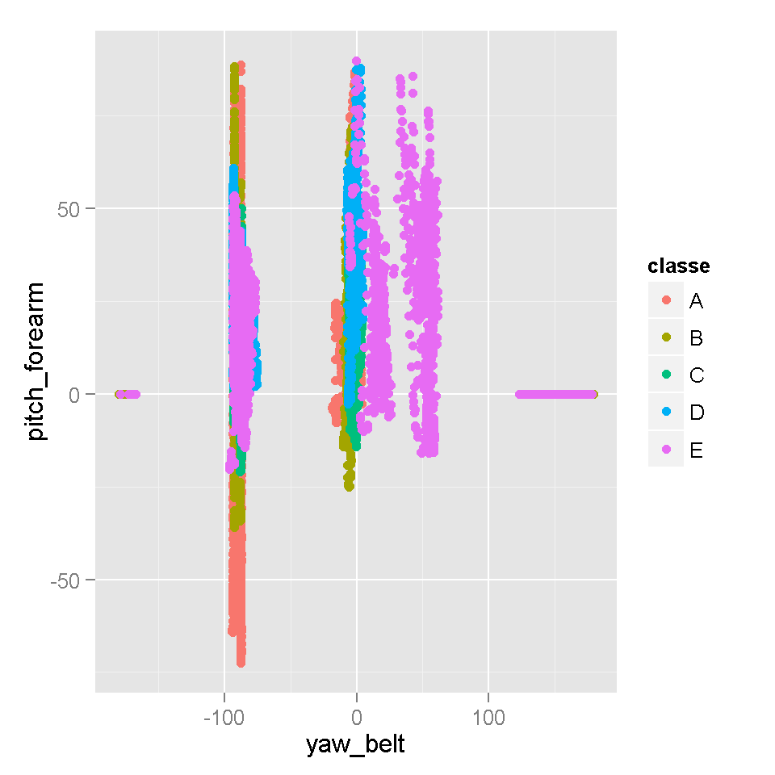

```r
qplot(yaw_belt, pitch_forearm,colour=classe,data=training)
```

**Cross Validation** Checking the fitted model on the testing data

```r
predictions <- predict(modelFit,newdata=testing[,-ncol(testing)])
table(predictions,testing$classe)
```

```
##
## predictions    A    B    C    D    E
##           A 1056  243  128  111    9
##           B    0    0    0    0    0
##           C  209  474  615  422  310
##           D  130  232  112  270  142
##           E    0    0    0    1  440
```

```r
confusionMatrix(predictions,testing$classe)
```

```
## Confusion Matrix and Statistics
##
##           Reference
## Prediction    A    B    C    D    E
##          A 1056  243  128  111    9
##          B    0    0    0    0    0
##          C  209  474  615  422  310
##          D  130  232  112  270  142
##          E    0    0    0    1  440
##
## Overall Statistics
##
##                Accuracy : 0.486
##                  95% CI : (0.471, 0.5)
##     No Information Rate : 0.284
##     P-Value [Acc > NIR] : <2e-16
##
##                   Kappa : 0.35
##  Mcnemar's Test P-Value : NA
##
## Statistics by Class:
##
##                      Class: A Class: B Class: C Class: D Class: E
## Sensitivity             0.757    0.000    0.719   0.3358   0.4883
## Specificity             0.860    1.000    0.651   0.8498   0.9998
## Pos Pred Value          0.683      NaN    0.303   0.3047   0.9977
## Neg Pred Value          0.899    0.806    0.916   0.8671   0.8967
## Prevalence              0.284    0.194    0.174   0.1639   0.1837
## Detection Rate          0.215    0.000    0.125   0.0551   0.0897
## Detection Prevalence    0.315    0.000    0.414   0.1807   0.0899
## Balanced Accuracy       0.809    0.500    0.685   0.5928   0.7440
```

Plotting the classification tree

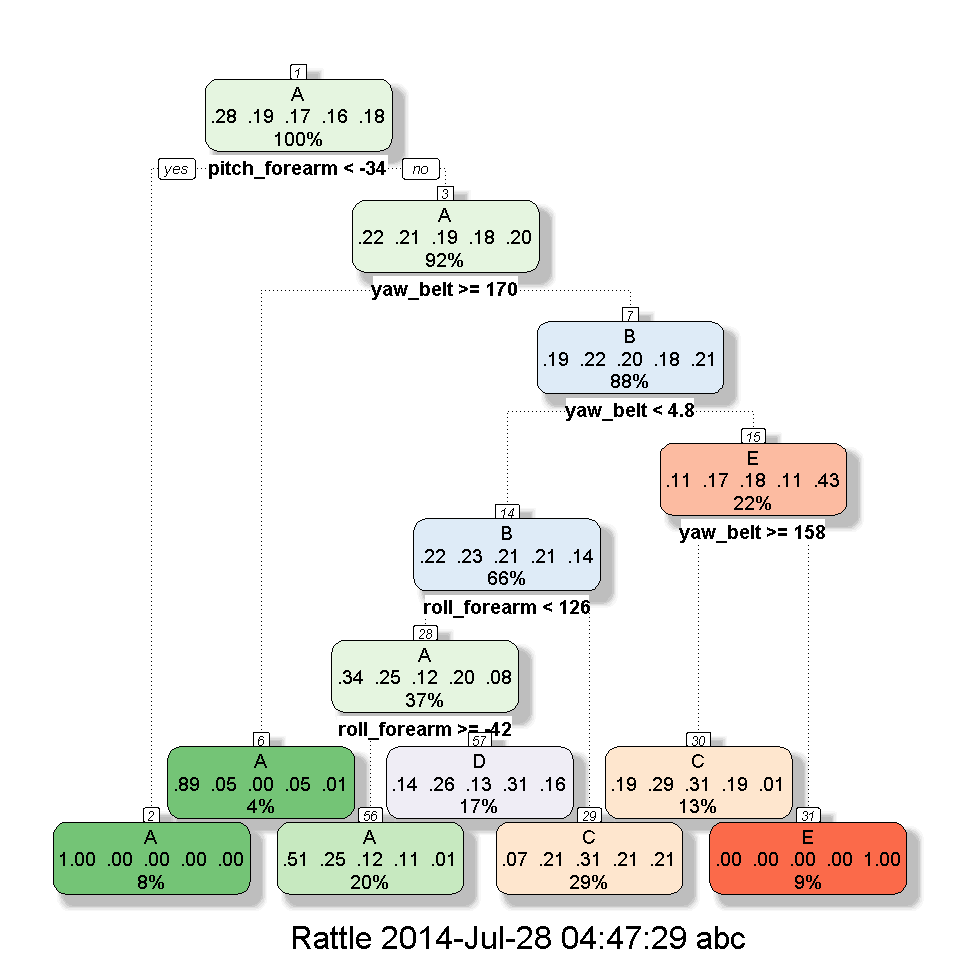

```r
fancyRpartPlot(modelFit$finalModel)
```

[figure not shown]

```r
plot(modelFit$finalModel, uniform=TRUE, main="Classification Tree")
text(modelFit$finalModel, use.n=TRUE, all=TRUE, cex=0.8)
```

**Running the prediction on the validation data**

```r
testData <- read.csv('pml-testing.csv',header=T)
predictions <- predict(modelFit,newdata=testData)
print(predictions)
```

```
##  [1] C A C C D C C D A A C C C A C D A D D C
## Levels: A B C D E
```